# An overview of anscombiser

Paul Northrop

2022-10-03

The `anscombiser` package is named after the famous Anscombe’s quartet datasets (Anscombe (1973)). Frank Anscombe created these datasets to emphasize the importance of graphical techniques in statistical analyses. The datasets each consist of 11 pairs of $(x, y)$ points and they have almost exactly the same values of an apparently remarkable number of sample summary statistics. However, scatter plots of these data reveal that the behaviours exhibited in these datasets are very different. That inspecting summary statistics can give a very misleading impression of a dataset is an important point for students of Statistics to appreciate.

## Creating datasets with identical summary statistics

The `datasauRus` package (Locke and D’Agostino McGowan (2018)) provides further examples of datasets that have markedly different scatter plots but nevertheless share many sample summary statistics. These datasets were produced by using a simulated annealing algorithm that seeks to morph incrementally an initial dataset towards a target shape while maintaining the same sample summary statistics (Matejka and Fitzmaurice (2017)). In principle, any set of summary statistics can be used. Indeed, Locke and D’Agostino McGowan (2018) provides not only datasets that have the same values of Anscombe’s statistics (essentially sample means, variances and correlation) but also datasets that are constrained to share the same sample median, interquartile range and Spearman’s rank correlation.

The `anscombiser` package takes a simpler and quicker approach to the same problem, using Anscombe’s statistics. It uses shifting, scaling and rotating to transform the observations in an input dataset to achieve a target set of Anscombe’s statistics. These statistics can be set directly or by calculating them from a target dataset, perhaps one of Anscombe’s quartet. If the input dataset has statistics that are similar to the target statistics then the output dataset will look rather similar to the input dataset. Otherwise, the output dataset will be a squashed and/or rotated version of the input dataset, but the general shape of the input dataset will still be visible. It will be like viewing the input dataset from a different perspective.

Thus, we can easily create many datasets that have different general natures but share the same values of Anscombe’s statistics. In addition, this method works in more than two dimensions.

```r
library(anscombiser)
```

### Anscombe’s quartet

The `anscombise()` function takes an input two-dimensional dataset and outputs a dataset that shares Anscombe’s statistics with his quartet of datasets. The `which` argument chooses which of Anscombe’s datasets to use. The default is `which = 1`. Of course, this affects the output dataset only minimally but it matters if we want to plot the input dataset, as we do in an example below.

The `anscombiser` packages provides 8 input files: `input1` to `input8` that can be used to create Anscombe-like, with the same sample size of 11 as the original Anscombe quartet. The following example uses input data arranged on the edge of a circle.

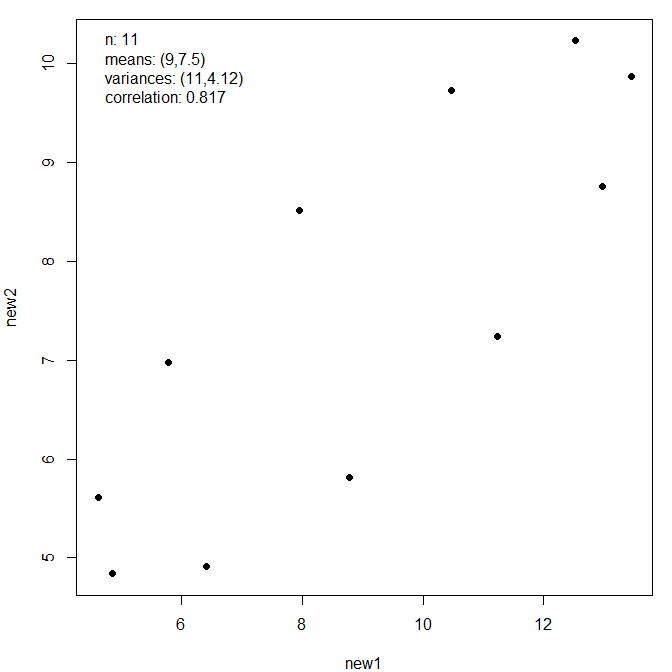

```r
a2 <- anscombise(input2, which = 4)
plot(a2)
```

Now we transform the Old Faithful Geyser data so that it shares the sample summary statistics of the Anscombe quartet.

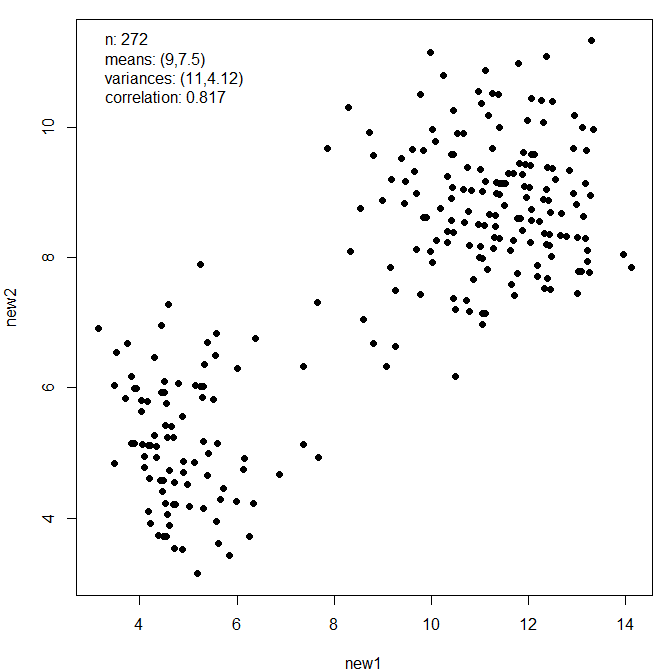

```r
new_faithful <- anscombise(datasets::faithful, which = 4)
plot(new_faithful)
```

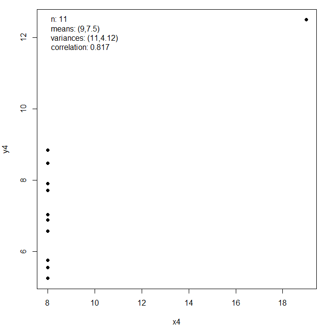

```r
plot(new_faithful, input = TRUE)
```

If we view a plot of the outline of the coast of Italy from a strange angle then the resulting dataset has the same sample summary statistics as those above.

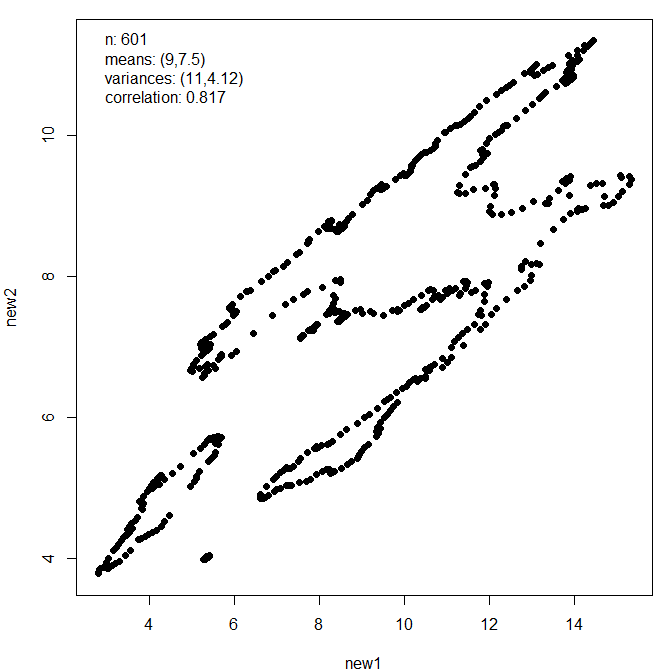

```r
italy <- mapdata("Italy")
new_italy <- anscombise(italy, which = 4)
plot(new_italy)
```

### Other two-dimensional examples

The `mimic()` function of the `anscombiser` package transforms an input dataset, as outlined above, to mimic another dataset, in the sense of replicating its values of Anscombe’s statistics. A particularly effective feature of the `datasauRus` package is a dataset that draws a picture of a dinosaur. Here, we show that a plot of the outline of the coast of the UK needs little adjustment to replicate the sample summary statistics of the dinosaur dataset.

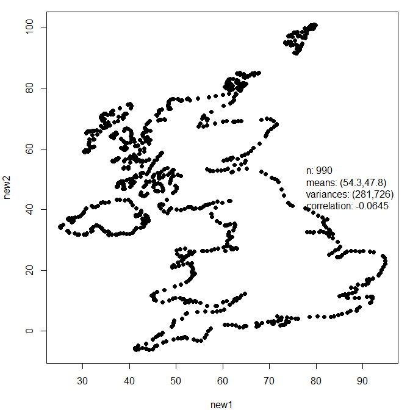

```r
library(datasauRus)
library(maps)
dino <- datasaurus_dozen_wide[, c("dino_x", "dino_y")]
UK <- mapdata("UK")
new_UK <- mimic(UK, dino)
plot(new_UK, legend_args = list(x = "right"))
```

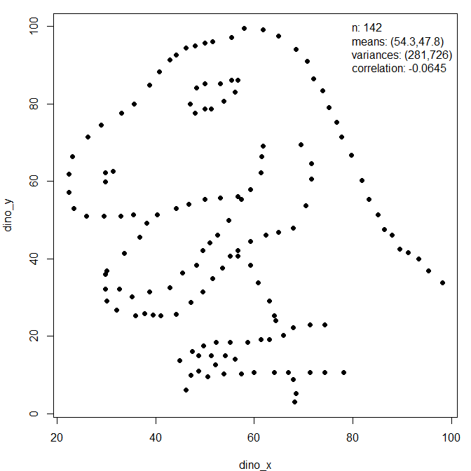

```r
plot(new_UK, input = TRUE, legend_args = list(x = "topright"))
```

We finish this section with another example involving the dinosaur.

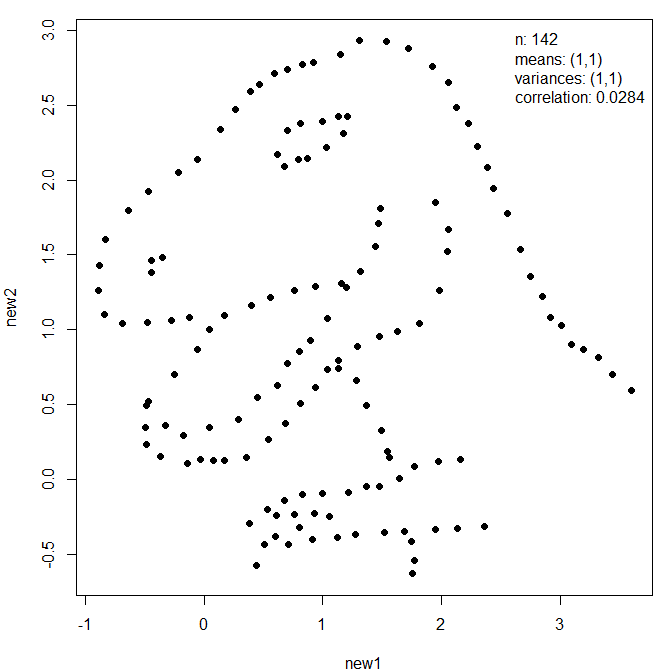

```r
new_dino <- mimic(dino, trump)
plot(new_dino, legend_args = list(x = "topright"))
```

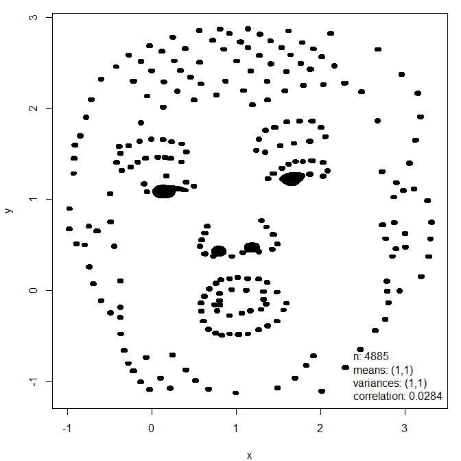

```r
plot(new_dino, input = TRUE, legend_args = list(x = "bottomright"), pch = 20)
```

The final image was created by [Accentaur from the Noun Project](https://thenounproject.com/term/donald-trump/727774/).

### Three-dimensional examples

We conclude with a brief 3D example, using the `randu` and `trees` datasets in the `datasets` package.

```r
new_randu <- mimic(datasets::randu, datasets::trees)
# new_randu and trees share the same sample summary statistics
new_randu_stats <- get_stats(new_randu)
trees_stats <- get_stats(datasets::trees)
# For example
trees_stats$correlation
```

```
#>            Girth    Height    Volume
#> Girth  1.0000000 0.5192801 0.9671194
#> Height 0.5192801 1.0000000 0.5982497
#> Volume 0.9671194 0.5982497 1.0000000
```

```r
new_randu_stats$correlation
```

```
#>           new1      new2      new3
#> new1 1.0000000 0.5192801 0.9671194
#> new2 0.5192801 1.0000000 0.5982497
#> new3 0.9671194 0.5982497 1.0000000
```

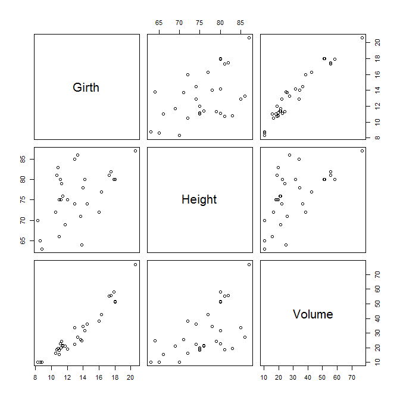

```r
pairs(trees)
```

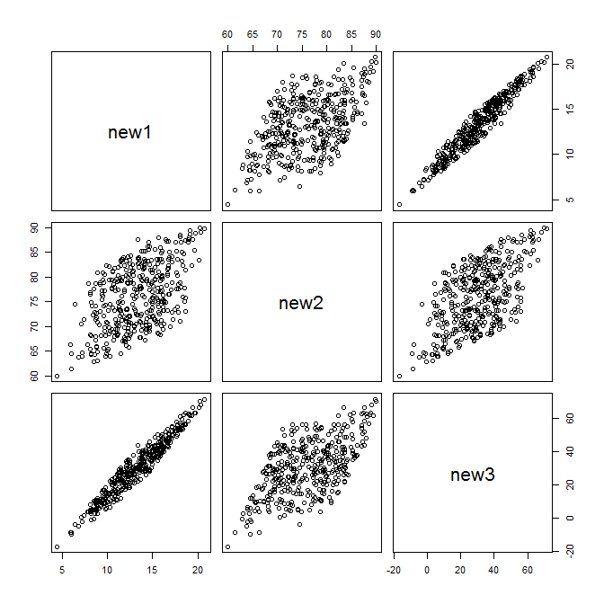

```r
pairs(new_randu)
```

It is well-known that in three-dimensional displays of the `randu` data non-random structure is evident, but this isn’t evident in these pairwise displays.

Anscombe, F. J. 1973. “Graphs in Statistical Analysis.” *The American Statistician* 27 (1). Taylor & Francis: 17–21. doi:10.1080/00031305.1973.10478966.

Locke, Steph, and Lucy D’Agostino McGowan. 2018. *datasauRus: Datasets from the Datasaurus Dozen*. https://CRAN.R-project.org/package=datasauRus.

Matejka, Justin, and George Fitzmaurice. 2017. “Same Stats, Different Graphs: Generating Datasets with Varied Appearance and Identical Statistics Through Simulated Annealing.” Autodesk Research, Toronto, Ontario, Canada. https://www.autodesk.com/research/publications/same-stats-different-graphs.